# IODS-final

Jonas Harjunpää, jonas.harjunpaa@helsinki.fi

March 4, 2017

# IODS-final project

## Abstract

In my final assignment I tested how hobbies relate to gender and age. This was done on the hobbies data included in the FactomineR package. The study was done using Multiple Correspondence Analysis on the data set, which consisted of categorical variables. The hypothesis were that younger people being more likely to have hobbies and typical stereotype hobbies as fishing or knitting are more common with genders. Based on this study it seems as if the data supported the hypothesis.

## IODS-final project and my hypothesis

As my final project in the course Introduction to Open Datasciences, I am going to perform Multiple correspondence analysis on Factominers Hobbies dataset, to draw some conclusions about how hobbies relate to age and gender.

My hypothesis is that younger persons tend to have more hobbies than older people, since they have more time than older people and most of us have had at least one hobby when we were young. Also the older people get the less time they have and when people become really old they don’t have the energy anymore to do so many things. Also going with stereotypes, I think young men are more likely to have computer as a hobby, while knitting is more common with elderly women. I also suspect that mechanics and fishing are more common with men, meanwhile women might be more actively reading or visiting exhibitions

## The original dataset and the wrangling of it

[Here is a link to my wrangled the data.](https://github.com/Jonharju/IODS-final/blob/master/final_wrangling_hobbies.R) The data is from the Factominer package, it’s based on a questionnaire about hobbies. The original data consisted 8403 observations of 23 variables, out which 18 were hobbies and then there was a count of how many hobbies out of the 18 were practised. The remaining four described the person, like age, marital status, sex and profession.

After the wrangling there are 6905 observations of 14 variables. Incomplete variables were removed and also some general hobbies like listening to music or going to cinema, which I found quite common and therefore the others more interesting. Also renaming of the factors was done to describe them better than 0 or 1.

## A look at the data

```r
library(dplyr)
hobbies<- read.table("~/GitHub/IODS-final/hobbies.csv", sep = ",", header = TRUE)
hobbies<- select(hobbies, -X)
str(hobbies)
```

```
## 'data.frame':    6905 obs. of  14 variables:
##  $ Reading      : Factor w/ 2 levels "No reading","Reading": 2 2 2 1 1 2 2 2 2 2 ...
##  $ Computer     : Factor w/ 2 levels "Computer","No computer": 2 2 2 2 1 1 2 2 2 1 ...
##  $ Sport        : Factor w/ 2 levels "No sport","Sport": 2 1 1 1 2 2 1 2 1 2 ...
##  $ Walking      : Factor w/ 2 levels "No walking","Walking": 2 1 2 1 1 2 1 1 2 1 ...
##  $ Travelling   : Factor w/ 2 levels "No travelling",..: 2 2 1 1 1 2 1 1 2 2 ...
##  $ Playing.music: Factor w/ 2 levels "No playing music",..: 1 1 1 1 1 2 2 1 1 1 ...
##  $ Volunteering : Factor w/ 2 levels "No volunteering",..: 2 1 1 1 1 1 1 1 1 1 ...
##  $ Mechanic     : Factor w/ 2 levels "Mechanic","No mechanic": 1 2 2 1 1 2 1 2 2 2 ...
##  $ Gardening    : Factor w/ 2 levels "Gardening","No gardening": 2 2 2 2 2 2 1 2 2 2 ...
##  $ Knitting     : Factor w/ 2 levels "Knitting","No knitting": 2 2 2 2 2 2 2 2 2 2 ...
##  $ Cooking      : Factor w/ 2 levels "Cooking","No cooking": 2 2 2 2 2 2 2 2 2 2 ...
##  $ Fishing      : Factor w/ 2 levels "Fishing","No fishing": 2 2 2 2 2 2 2 2 2 2 ...
##  $ Sex          : Factor w/ 2 levels "F","M": 1 1 2 2 2 1 1 1 1 1 ...
##  $ Age          : Factor w/ 8 levels "(25,35]","(35,45]",..: 4 1 4 3 2 2 1 8 6 2 ...
```

So as I previously mentioned, the data consists of 12 hobbies as factor variables, which have the value hobby or not hobby. We also have age as varible, as slices of then years starting from 15-25 and ending at 86-100. Then there is sex, simply divided into M (male) or F (female).

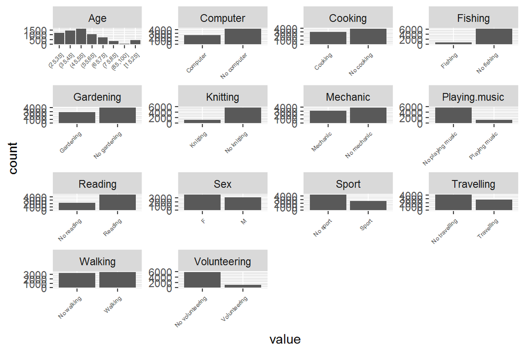

```r
library(tidyr)
library(ggplot2)
gather(hobbies) %>% ggplot(aes(value)) + facet_wrap("key", scales = "free") + geom_bar() + theme(axis.text.x = element_text(angle = 45, hjust = 1, size = 5))
```

Here is a graphical presentation of the data.

```r
summary(hobbies)
```

```
##        Reading            Computer         Sport            Walking
##  No reading:2265   Computer   :2609   No sport:4361   No walking:3378
##  Reading   :4640   No computer:4296   Sport   :2544   Walking   :3527
##
##
##
##
##
##          Travelling            Playing.music           Volunteering
##  No travelling:4098   No playing music:5731   No volunteering:5820
##  Travelling   :2807   Playing music   :1174   Volunteering   :1085
##
##
##
##
##
##         Mechanic           Gardening           Knitting
##  Mechanic   :3037   Gardening   :2837   Knitting   :1180
##  No mechanic:3868   No gardening:4068   No knitting:5725
##
##
##
##
##
##        Cooking           Fishing     Sex           Age
##  Cooking   :3076   Fishing   : 783   F:3772   (45,55]:1624
##  No cooking:3829   No fishing:6122   M:3133   (35,45]:1455
##                                               (25,35]:1183
##                                               (55,65]:1067
##                                               (65,75]: 713
##                                               [15,25]: 456
##                                               (Other): 407
```

Here we can see some summaries on the varibles. The only hobby for clearly over half of the participants was Reading, with around 2/3 reading. Close to half and half were Walking, Cooking and Mechanic. Slightly ufavoured were Computer, Sport, Travelling and Gardening. Clearly unfavored were Knitting, Playing music, Volunteering and Fishing with around 1/7 of the participants counting it as their hobby. I was surprised with Mechanic being so common and Playing music being so uncommon.

The participants were quite close to being even in gender, with slightly more Female participants. Because age and profession are not shown as whole, let’s summarize just them again.

```r
summary(hobbies$Age)
```

```
##  (25,35]  (35,45]  (45,55]  (55,65]  (65,75]  (75,85] (85,100]  [15,25]
##     1183     1455     1624     1067      713      348       59      456
```

We can see that age of the participants was quite evenly distributed towards the middle with the ends as the smallest groups, with a little more weight on the younger side. Most of the participants were between 25 and 65 years old, while the smallest group was 86-100. This could be expected.

## Multiple correspondence analysis as a method

Multiple correspondence analysis is a dimensionality reduction technique. It is used to find correlations and structures between the categorical varibles. It is basically an extencison of correspondence analysis, which is similar to principal component analysis, but differs in that it applies to categorical instead of continuous data. The reduction of dimensions is done by representing data as points in a low-dimensional Euclidean space.

## My analysis

```r
library(FactoMineR)
mca <- MCA(hobbies, graph = FALSE)
# summary of the model
summary(mca)
```

```
##
## Call:
## MCA(X = hobbies, graph = FALSE)
##
##
## Eigenvalues
##                        Dim.1   Dim.2   Dim.3   Dim.4   Dim.5   Dim.6
## Variance               0.176   0.129   0.106   0.082   0.073   0.073
## % of var.             12.335   9.016   7.418   5.733   5.120   5.092
## Cumulative % of var.  12.335  21.352  28.770  34.503  39.622  44.715
##                        Dim.7   Dim.8   Dim.9  Dim.10  Dim.11  Dim.12
## Variance               0.072   0.072   0.071   0.066   0.066   0.061
## % of var.              5.043   5.018   4.995   4.652   4.612   4.254
## Cumulative % of var.  49.758  54.776  59.771  64.423  69.035  73.288
##                       Dim.13  Dim.14  Dim.15  Dim.16  Dim.17  Dim.18
## Variance               0.058   0.055   0.053   0.052   0.050   0.046
## % of var.              4.036   3.854   3.686   3.632   3.515   3.195
## Cumulative % of var.  77.325  81.179  84.865  88.497  92.012  95.207
##                       Dim.19  Dim.20
## Variance               0.037   0.031
## % of var.              2.603   2.190
## Cumulative % of var.  97.810 100.000
##
## Individuals (the 10 first)
##                  Dim.1    ctr   cos2    Dim.2    ctr   cos2    Dim.3
## 1             |  0.344  0.010  0.082 | -0.095  0.001  0.006 |  0.203
## 2             | -0.279  0.006  0.085 | -0.134  0.002  0.020 | -0.385
## 3             | -0.384  0.012  0.159 |  0.053  0.000  0.003 |  0.185
## 4             | -0.499  0.020  0.270 |  0.414  0.019  0.185 |  0.153
## 5             | -0.048  0.000  0.002 |  0.630  0.045  0.356 | -0.276
## 6             |  0.496  0.020  0.186 | -0.094  0.001  0.007 | -0.518
## 7             |  0.012  0.000  0.000 | -0.042  0.000  0.001 | -0.084
## 8             | -0.306  0.008  0.058 |  0.067  0.001  0.003 | -0.705
## 9             | -0.356  0.010  0.066 | -0.335  0.013  0.059 | -0.081
## 10            |  0.134  0.001  0.018 |  0.014  0.000  0.000 | -0.534
##                  ctr   cos2
## 1              0.006  0.028 |
## 2              0.020  0.161 |
## 3              0.005  0.037 |
## 4              0.003  0.025 |
```

[output cut: 28 more lines]

```
## No travelling   4.534 |  -0.011   0.005   0.000  -1.079 |
## Travelling     -4.534 |   0.016   0.007   0.000   1.079 |
##
## Categorical variables (eta2)
##                 Dim.1 Dim.2 Dim.3
## Reading       | 0.195 0.107 0.004 |
## Computer      | 0.355 0.051 0.161 |
## Sport         | 0.321 0.033 0.072 |
## Walking       | 0.222 0.023 0.069 |
## Travelling    | 0.325 0.003 0.000 |
## Playing.music | 0.197 0.008 0.029 |
## Volunteering  | 0.131 0.002 0.027 |
## Mechanic      | 0.242 0.123 0.093 |
## Gardening     | 0.118 0.003 0.370 |
## Knitting      | 0.019 0.436 0.005 |
```

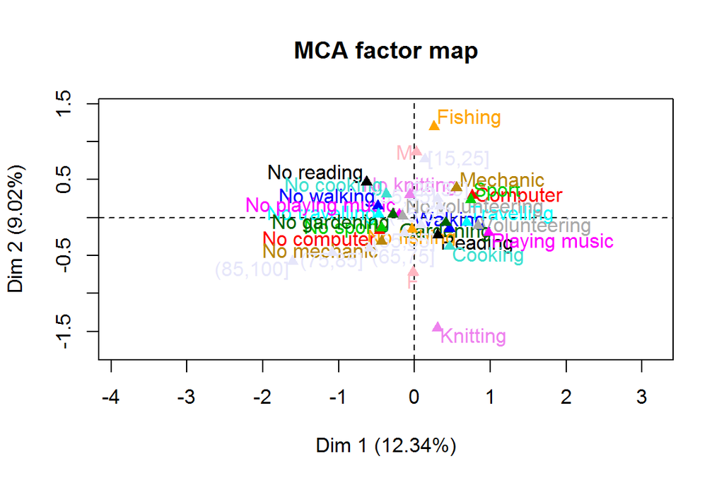

```r
# visualize MCA
plot(mca, invisible=c("ind"), habillage = "quali")
```

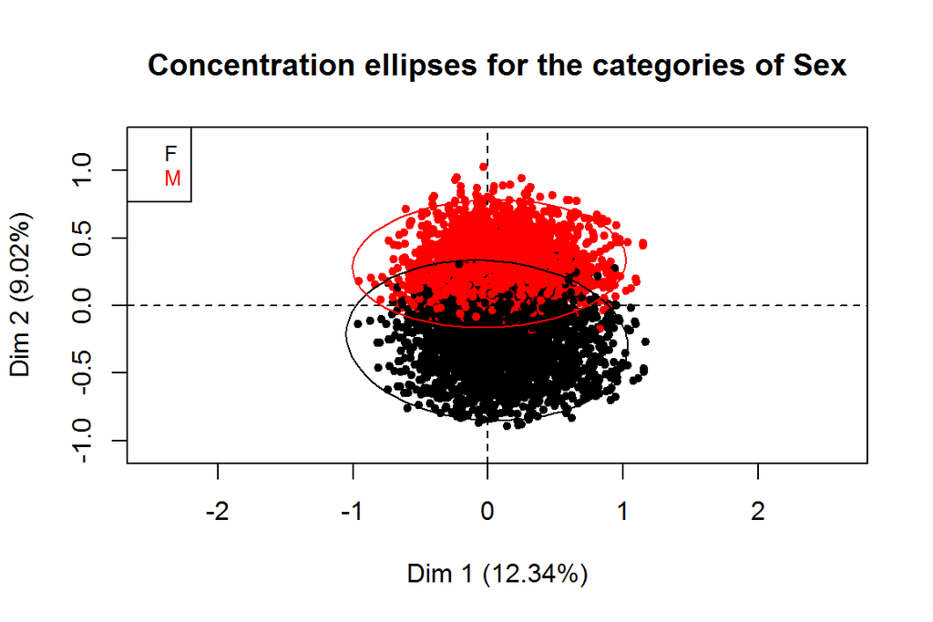

```r
# visualize MCA
plotellipses(mca, keepvar = 13, means = FALSE, label = "quali")
```

As we can see the genders are distributed the way as expected. The splitting suggests that Based on my theory and the fact that fishing is deviating high on dimension 2, while knitting is deviating low suggests that the second dimension would correlate with gender. This would seem to go very well with my hypothesis.

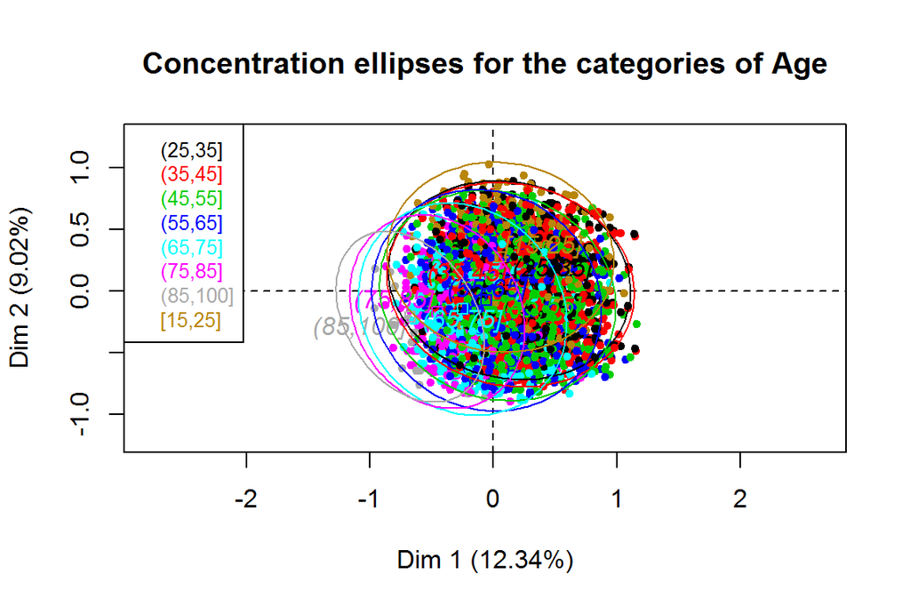

```r
# visualize MCA
plotellipses(mca, keepvar = 14, means = FALSE, label = "quali")
```

We can see that the greater ages are going from the inward, but the yonger groups don’t follow the pattern all the way, as the rightmost ellips is the 35-45. There would still seem to some correlatione with age and dimension 1. Based on the fact that many of the not having something as hobby were on the negative side of the first dimension, it would seem to fit well with my hypothesis.

## Discussions and conclusions

This assignment focused on how age and gender is related to hobbies. My hypothesis were that younger people are more likely to have hobbies and that typically hobbies considered masculine as fishing or feminine as knitting are more common among the stereotypes. After some Multiple Correspondence Analysis on the data, there is some evidence for my hypothesis. The case for genders was more clearly divided, while the age was not so straight forward. This does not mean that we can claim this to be true in all cases, but the data seems to match the typical stereotypes.